# The P Hydro model with sperry optimization

Victor Flo

2022-08-01

The ProfitMax stomatal scheme (Sperry et al. 2016) is obtimised as:
$$F_{ProfitMax} = \frac{A_j}{A_{max}}
- (\frac{k_\mathrm{\psi_s}-k_\mathrm{\psi_l}}{k_\mathrm{\psi_s}-k_\mathrm{\psi_{crit}}})$$
The profit maximization can be rewritten as:
$$F_{ProfitMax} = A_j - A_{max}
(\frac{k_\mathrm{\psi_s}-k_\mathrm{\psi_l}}{k_\mathrm{\psi_s}-k_\mathrm{\psi_{crit}}})$$
Then we can easily account for photosynthetic cost:
$$F = A_j - A_{max}
(\frac{k_\mathrm{\psi_s}-k_\mathrm{\psi_l}}{k_\mathrm{\psi_s}-k_\mathrm{\psi_{crit}}})
- \alpha J_\mathrm{max}$$

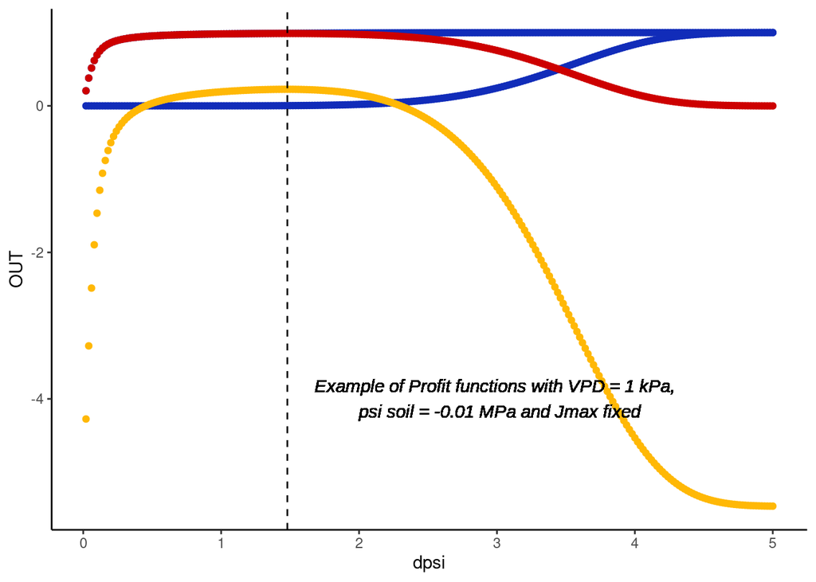

The components of the profit maximization function can be rewritten as:
$$A_j = g_\mathrm{s} c_\mathrm{a} (1-\chi)$$

$$k_\mathrm{\psi_s} =
K_{max}\;(\frac{1}{2})^{(\frac{\psi_s}{\psi_{50}})^b}$$

$$k_\mathrm{\psi_l} =
K_{max}\;(\frac{1}{2})^{(\frac{\psi_l}{\psi_{50}})^b} =
K_{max}\;(\frac{1}{2})^{(\frac{\Delta\psi + |\psi_s|}{|\psi_{50}|})^b}$$

$$k_\mathrm{\psi_{crit}} =
K_{max}\;(\frac{1}{2})^{(\frac{\psi_{crit}}{\psi_{50}})^b}$$

Where $\psi_{crit}$ is the critical leaf water potential as the potential at which 99.9% of conductivity loss would occur.

$$P(\psi) = \frac{1}{2} ^{(\frac{\psi}{\psi_{50}})^b}$$

$$if\; P(\psi) = 0.001 \; then: \; \psi_{crit} =
\psi_{50}(\frac{ln(1000)}{ln(2)} )^{(\frac{1}{b})}$$

Which gives us the next expression that can be solved similarly as in the P Hydro analytical approximation, where each term is a function of the two independent variables $\chi$ and $\Delta \psi$.
$$F = g_\mathrm{s} c_\mathrm{a} (1-\chi)- A_{max}
(\frac{k_\mathrm{\psi_s}- K_{max}\;(\frac{1}{2})^{(\frac{\Delta\psi +
|\psi_s|}{|\psi_{50}|})^b}}{k_\mathrm{\psi_s}-k_\mathrm{\psi_{crit}}}) -
\alpha J_\mathrm{max}$$

or:
$$F = g_\mathrm{s} c_\mathrm{a} (1-\chi)
(k_\mathrm{\psi_s}-k_\mathrm{\psi_{crit}})- A_{max} (k_\mathrm{\psi_s}-
K_{max}\;(\frac{1}{2})^{(\frac{\Delta\psi + |\psi_s|}{|\psi_{50}|})^b})
- \alpha J_\mathrm{max} (k_\mathrm{\psi_s}-k_\mathrm{\psi_{crit}})$$

Solved by $\chi$
$$\frac{\partial F}{\partial \chi} = -g_s
c_a(k_\mathrm{\psi_s}-k_\mathrm{\psi_{crit}}) -\alpha \frac{\partial
J_\mathrm{max}}{\partial A_{Jm}} \frac{\partial A_{Jm}}{\partial \chi}(
k_\mathrm{\psi_s}-k_\mathrm{\psi_{crit}}) = 0$$

Solved by $\Delta\psi$
$$\frac{\partial F}{\partial \Delta\psi} = \frac{\partial g_s}{\partial
\Delta\psi} c_a (1-\chi) (k_\mathrm{\psi_s}-k_\mathrm{\psi_{crit}})-
\frac{A_{max}\;K_{max}\;ln(2)\;(\frac{\Delta\psi +
|\psi_s|}{|\psi_{50}|})^b}{2\;(\Delta\psi + |\psi_s|)(\frac{\Delta\psi +
|\psi_s|}{|\psi_{50}|})^b}-
\alpha \frac{\partial J_\mathrm{max}}{\partial A_{Jm}} \frac{\partial
A_{Jm}}{\partial \Delta\psi}(k_\mathrm{\psi_s}-k_\mathrm{\psi_{crit}})=
0$$

Here I show surfaces obtained from the optimization function numerically at four different $\psi_{s}$, a) -0.01, b) -1, c) -2 and d) -3 MPa (VPD = 1kPa). In this case the critical leaf potential is -4.9149669 MPa.

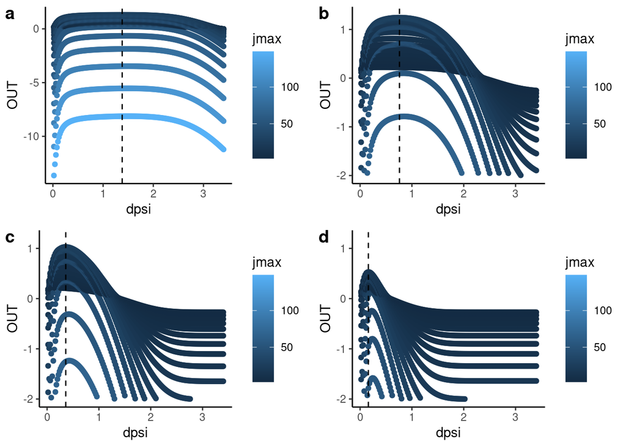

Now the same soil water potentials but expressed as Canopy conductance (gs)

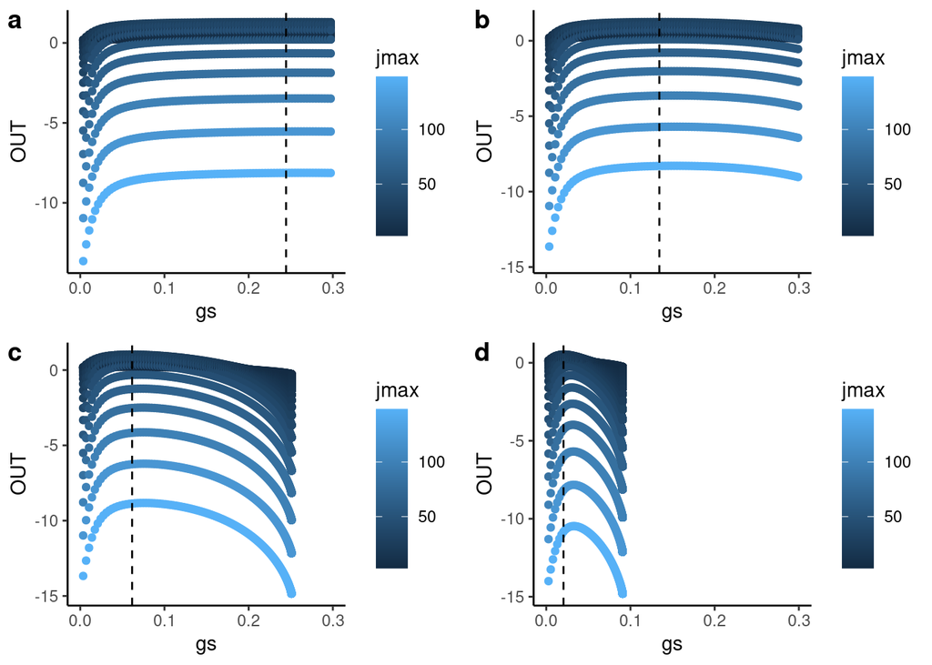

Here I show the simulations for the soil potential gradient. The plant have a $\psi_{50}$ = -3.46 a slope parameter of 6.55 and a $K$ of 3e-17

```
## [1] "WARNING: soil water potential is lower than critical plant water potential."
```

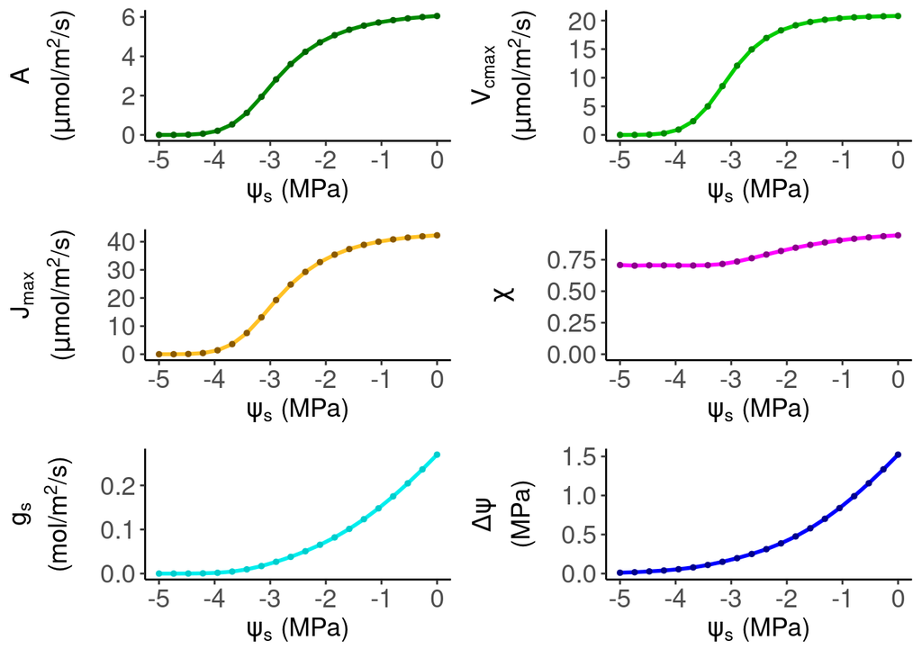

And here the simulations for VPD. Lines are simulations with $\psi_s$ equal to -1 MPa and dots -3 MPa.

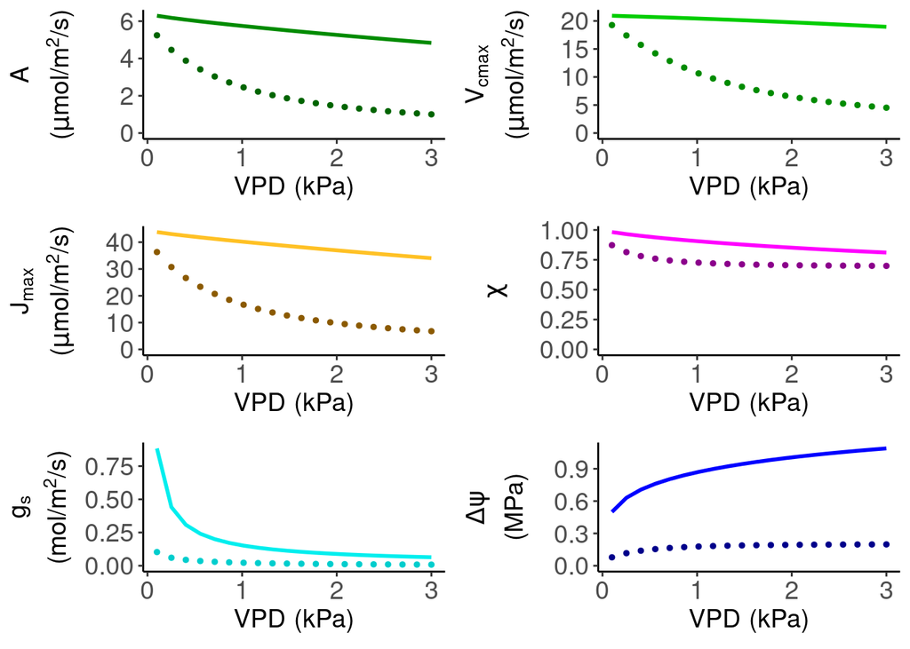